# R Notebook

```
install.packages("neonUtilities")
install.packages("exactextractr")
install.packages("lidR")
```

```r
library(neonUtilities)
library(sf)
library(lidR)
library(tidyverse)
```

First thing, we need to download the target area of interest form NEON. We will use the NEON utilities package and specifically the byTileAOP function to retrieve the tile of interest. We will be downloading 2 tiles: (1) the RGB orthophoto, the dpID being “DP1.30010.001”, used for detecting trees (2) the CHM, the dpID being “DP3.30015.001”, used for estimating the size of each predicted tree

We will be using OSBS data, year 2021. For this utorial, the Easting and Northign will be 402000 and 3286000

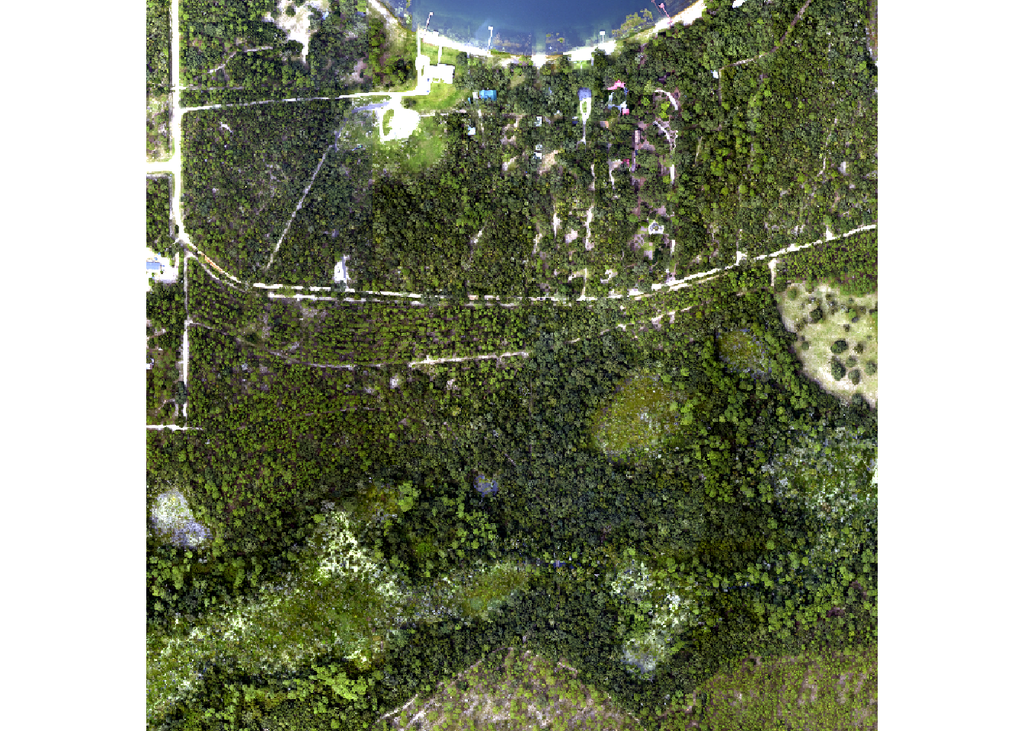

Now, let’s try to get crow predictions, shall we! The methods we are using today are based on generating polygons from the canopy height model. If we have time we will see how to do it by using state of teh art deep learning and RGB data. Because it may be too advanced, however, it will not be today’s “standard” approach… Maybe next year!

```
## Downloading files totaling approximately 4.03195 MB
## Downloading 6 files
##
  |
  |                                                                      |   0%
  |
  |==============                                                        |  20%
  |
  |============================                                          |  40%
  |
  |==========================================                            |  60%
  |
  |========================================================              |  80%
  |
  |======================================================================| 100%
## Successfully downloaded  6  files.
## NEON_D03_OSBS_DP1_402000_3286000_classified_point_cloud.shp downloaded to indir/DP3.30015.001/neon-aop-products/2021/FullSite/D03/2021_OSBS_6/Metadata/DiscreteLidar/TileBoundary/shps
## NEON_D03_OSBS_DP1_402000_3286000_classified_point_cloud.kml downloaded to indir/DP3.30015.001/neon-aop-products/2021/FullSite/D03/2021_OSBS_6/Metadata/DiscreteLidar/TileBoundary/kmls
## NEON_D03_OSBS_DP1_402000_3286000_classified_point_cloud.dbf downloaded to indir/DP3.30015.001/neon-aop-products/2021/FullSite/D03/2021_OSBS_6/Metadata/DiscreteLidar/TileBoundary/shps
## NEON_D03_OSBS_DP1_402000_3286000_classified_point_cloud.shx downloaded to indir/DP3.30015.001/neon-aop-products/2021/FullSite/D03/2021_OSBS_6/Metadata/DiscreteLidar/TileBoundary/shps
## NEON_D03_OSBS_DP1_402000_3286000_classified_point_cloud.prj downloaded to indir/DP3.30015.001/neon-aop-products/2021/FullSite/D03/2021_OSBS_6/Metadata/DiscreteLidar/TileBoundary/shps
## NEON_D03_OSBS_DP3_402000_3286000_CHM.tif downloaded to indir/DP3.30015.001/neon-aop-products/2021/FullSite/D03/2021_OSBS_6/L3/DiscreteLidar/CanopyHeightModelGtif
```

Because of time and internet limitaiton, we will be using the CHM directly for tree detection. Ideally we’d like to use either (1) LiDAR data, or (2) deep learning applications from RGB data. We’ll see later how to eventually use a deep learning application for tree detection on NEON data.

let’s check, how does it vary with elevation? let’s download the elevation data from NEON

```r
byTileAOP(dpID = "DP3.30024.001", site = "OSBS", year = 2021, easting = 402000,
          check.size = F, northing = 3286000, savepath = img_pt)

dem_path = list.files("indir/DP3.30024.001/", pattern = "_DTM.tif", recursive = T, full.names = T)
dem = raster::raster(dem_path)
```

Unfortunately the traditional extract function can be quite slow, as you noticed when extracting the CHM. To reduce the time required to extract information, let’s turn our polygons into points, getting the centroid for each individual tree

```r
tree_stems_points = sf::st_centroid(boxes_with_height)
```

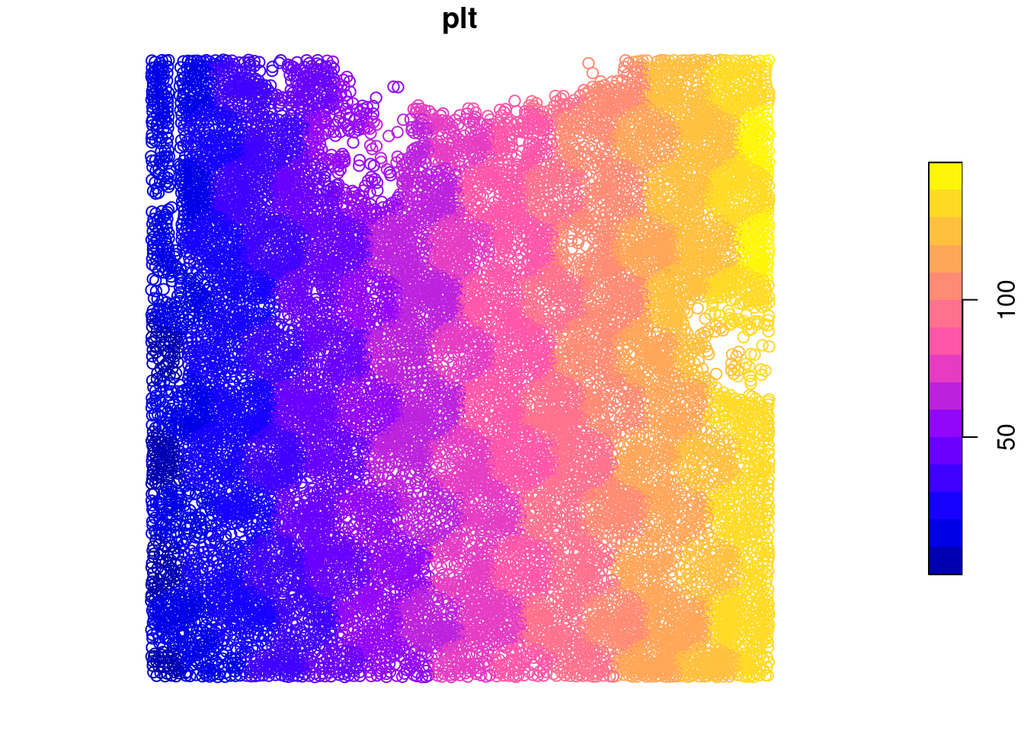

```r
elevation_at_tree_stems_points=raster::extract(dem, tree_stems_points)

tree_stems_points["elevation"] = elevation_at_tree_stems_points

grd = sf::st_as_sf(sf::st_make_grid(tree_stems_points, cellsize = 100, square = F))
grd$plt = 1:nrow(grd)
tree_stems_points = sf::st_join(tree_stems_points, grd)

plot(tree_stems_points["plt"])
```

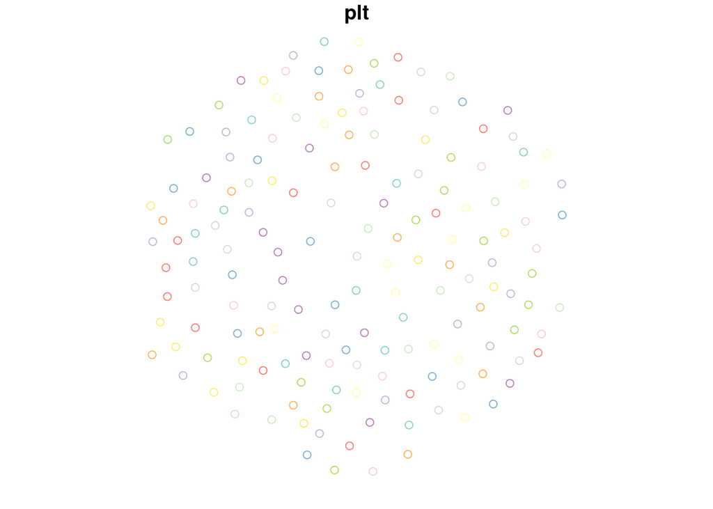

```r
tree_stems_points %>% dplyr::filter(plt ==37) %>% dplyr::select(plt) %>% plot(col = sf.colors(12, categorical = TRUE))
```

```r
#assign trees at the border between two plots to a single plot ID
tree_stems_points = tree_stems_points %>% dplyr::group_by(individual) %>% dplyr::slice(1)
```

However, we have now points, what if we want to append this information to the boxes? We can join by individual ID!

```r
tree_stems_points_df = data.frame(tree_stems_points) %>%
  dplyr::select(-one_of("geometry"))
boxes_with_height_and_elevation = dplyr::left_join(boxes_with_height,tree_stems_points_df )
```

Or more simply join by spatial feature. This should work in this case because the method used doesn’t allow two crowns to be overlapped. However, it may not be the case for results from cases where crowns overlap and a tree stem may be falling within the boundaries of multiple crowns. For this reason we would suggest to join by identifier, as suggested above

```
boxes_with_height_and_elevation_by_spatial = sf::st_join(boxes_with_height, tree_stems_points )
```

Now, we got trees, their size, their elevation… but we don’t have yet the measure of their diversity! That’s when the grid plotting comes handy!

Let’s get a simple quantification of variation: the gini index

```r
boxes_with_height_and_elevation = data.frame(boxes_with_height_and_elevation)
hmin = min(boxes_with_height_and_elevation$Height)
hmax = max(boxes_with_height_and_elevation$Height)
custom_bins = seq(hmin,hmax, by=5)
boxes_with_height_and_elevation = boxes_with_height_and_elevation %>%
  mutate(h_class = cut(Height, breaks = custom_bins))
#boxes_with_height_and_elevation$h_class = findInterval((boxes_with_height_and_elevation$Height), seq(from = 2, to = 40, by = 1))

h_div = boxes_with_height_and_elevation %>%
  dplyr::group_by(plt) %>%
  dplyr::mutate(n_trees_per_plot = n())
h_div = h_div %>% ungroup %>%
  dplyr::group_by(h_class, plt) %>%
  dplyr::mutate(hclass_n = n())

h_div = h_div %>% ungroup %>%
  dplyr::group_by(plt, h_class) %>%
  dplyr::slice(1)
h_div = h_div %>% dplyr::group_by(plt)  %>%
  dplyr::summarize(gini_numerator = sum(hclass_n *(hclass_n -1)),
            gini_denominator = unique(n_trees_per_plot)*(unique(n_trees_per_plot)-1),
            plot_elevation = mean(elevation),
            plot_max_height = max(Height))

h_div$GINI = 1- h_div$gini_numerator/h_div$gini_denominator
```

Now we have all the information we need! So, let’s finally check whether elevation affect size diversity in a transect from sandhill pine fores to wetland!

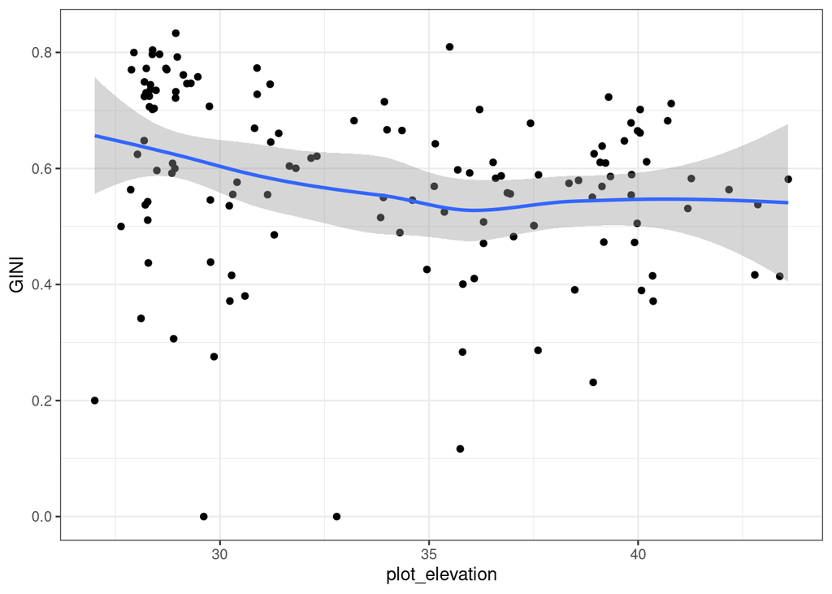

```r
ggplot(h_div, aes(x = plot_elevation, y = GINI)) + geom_point() + geom_smooth() + theme_bw()
```